# Statistics & Probability

Amruta Jadhav

##### Setup:

```r
# Load standard libraries
library(tidyverse)
```

### 1. Overbooking Flights

You are hired by to recommend the optimal overbooking rate. It is a small airline that uses a 100-seat plane to carry you from Seattle to, well, nowhere. The tickets cost $100 each, so a fully booked plane generates $10,000 revenue. The sales team has found that the probability, that the passengers who have paid their fare actually show up is 98%, and individual show-ups can be considered independent. The additional costs, associated with finding an alternative solutions for passengers who are refused boarding are $500 per person.

1. Which distribution would you use to describe the actual number of show-ups for the flight?

**Solution:** The outcome is binary that is either show-up or no show-up and individual show ups are independent. So, I will use the binomial distribution.

2. Assume the airline never overbooks. What is it’s expected profit? Expected profit means expected income/revenue from the ticket sales, minus the expected costs related to alternative solutions.

**Solution:** As mentioned in the question, airline never overbooks so the expected income will be $10,000 assuming that airline is able to book all 100 seats.

3. Now assume the airline sells 101 tickets for 100 seats. What is the probability that all 101 passengers will show up?

**Solution:** The probability that a individual passenger who paid their fare, show up is 98%. So the probability that 101 show up = (0.98)^101. So the probability is 0.129.

```r
a <- (0.98)^101
a
```

```
## [1] 0.1299672
```

4. What are the expected profits ($=$ revenue $-$ expected additional costs) in this case? Would you recommend overbooking over selling just the right number of tickets?

**Solution:**  
I will recommend over booking as expected profit for 101 bookings is slightly more than that of 100 bookings.

```r
Revenue <- 101 * 100
expected_additional_cost <- 0.1299 * 500

Expected_profit = Revenue - expected_additional_cost
Expected_profit
```

```
## [1] 10035.05
```

5. Now assume the airline sells 102 tickets. What is the probability that all 102 passengers show up?

**Solution:**  
The probability that a individual passenger who paid their fare, show up is 98%. So the probability that 101 show up = (0.98)^102. So the probability is 0.127.

```r
b <- (0.98)^102
b
```

```
## [1] 0.1273678
```

6. What is the probability that 101 passengers – still one too many – will show up?

**Solution:**  
The probability that 101 passengers show up is (0.98)^101 The probability that 1 passenger out of 102 does not show up is 0.02. There are 102 ways in which 101 passengers will show up and 1 will not. Therefore, probability of 101 out of 102 showing up is:

```r
prob_101_outof_102 <- 102 * (((0.98)^101) * 0.02)

prob_101_outof_102
```

```
## [1] 0.265133
```

7. Would it be advisable to sell 102 tickets, i.e. is the expected revenue from selling 102 tickets larger than from selling 100 and 101 tickets?

```r
prob_102_outof_102 <- ((0.98)^102)
prob_102_outof_102
```

```
## [1] 0.1273678
```

```r
Revenue_102 <- 102 * 100
#Expected cost for 101 out 102 passengers showing up
Expected_add_cost_101by102 <- 0.265 * 500

#Expected cost for 102 out 102 passengers showing up
Expected_add_cost_102by102 <- 0.127 * (2*500)

#Total expected additional cost
expected_add_cost <- Expected_add_cost_101by102 + Expected_add_cost_102by102

Expected_profit_102 <- Revenue_102 - expected_add_cost

Expected_profit_102
```

```
## [1] 9940.5
```

8. What is the optimal number of seats to sell for the airline? How big are the expected profits?

**Solution:** The optimal number of seats for airline is 101 seats. The profit is 10035 USD which is noy much greater than 10000 USD

9. What does it mean that the show-ups are independent? Why is it important in this case?

**Solution:**  
The show-ups are independent means that occurrence of one person showing up to board the flight does not depend on other person’s show-up. It is important in this case because if one persons show-up would have been dependent on another it would have impacted the expected profit. Also, it would have been difficult to estimate the additional cost.

Note: some of the expressions may be hard to write analytically. Feel free to use computer for the calculations, just show the code and explain what you are doing.

### 2. The Normal Distribution

We will explore data and ask whether it is approximately normal. We will consider two different datasets, one on height and one of research paper citations.

#### (a) Let’s start with the human height data.

```r
#Load standard libraries

library('dplyr')
library('stringr')
library('tibble')
require(modeest)
#Importing data

height_data <- readr::read_csv("C:\\CodeR - DataSci1\\PS-5\\fatherson.csv.bz2")
colnames(height_data)
```

```
## [1] "fheight\tsheight"
```

```r
glimpse(height_data)
```

```
## Rows: 1,078
## Columns: 1
## $ `fheight\tsheight` <chr> "165.2\t151.8", "160.7\t160.6", "165\t160.9", "1...
```

```r
#Data Cleaning
#Separating the two variables and creating new column

heights <- data.frame(do.call('rbind', strsplit(as.character(height_data$`fheight   sheight`), "\t", fixed = TRUE)))

#Converting character to integer

df_height <- as.data.frame(sapply(heights, as.numeric))

#Changing column name

colnames(df_height)[colnames(df_height) == 'X1'] <- 'fheight'

colnames(df_height)[colnames(df_height) == 'X2'] <- 'sheight'

glimpse(df_height)
```

```
## Rows: 1,078
## Columns: 2
## $ fheight <dbl> 165.2, 160.7, 165.0, 167.0, 155.3, 160.1, 166.0, 164.4, 167...
## $ sheight <dbl> 151.8, 160.6, 160.9, 159.5, 163.3, 163.2, 162.8, 162.5, 164...
```

1. What kind of measure is human height (nominal, ordinal, interval, ratio)? How should it be measured (e.g. continuous, discrete, positive, negative…)?

**Solution:**  
Human height is a ratio variable. The height will be measured as continuous and positive.

2. Read the dataset into R. It contains two columns, father’s height and son’s height, (in cm). Let’s focus on father’s height for a moment, (variable ). Provide a basic description of this variable, for example how many observations do we have? Do we have any missing data?

**Solution:**

There are 1078 obersvations in the fheight variable. As we can see below, there are no missing values or zeros.

```r
#Inspecting fheight for missing values
glimpse(df_height)
```

```
## Rows: 1,078
## Columns: 2
## $ fheight <dbl> 165.2, 160.7, 165.0, 167.0, 155.3, 160.1, 166.0, 164.4, 167...
## $ sheight <dbl> 151.8, 160.6, 160.9, 159.5, 163.3, 163.2, 162.8, 162.5, 164...
```

```r
colSums(is.na(df_height))
```

```
## fheight sheight
##       0       0
```

```r
filter(df_height, df_height == 0)
```

```
## [1] fheight sheight
## <0 rows> (or 0-length row.names)
```

3. Compute mean, median, mode, standard deviation and range of the heights. Discuss the relationship between these numbers. Is mean larger than median? Than mode? By how much (in relative terms)? What does this suggest? How does standard deviation compare to mean?

**Solution:**

```r
# mean, median, mode, sd and range of fheight

mean(df_height$fheight)
```

```
## [1] 171.9252
```

```r
median(df_height$fheight)
```

```
## [1] 172.1
```

```r
mlv(df_height$fheight, na.rm = TRUE, method = "mfv")
```

```
## [1] 175.4
```

```r
sd(df_height$fheight)
```

```
## [1] 6.972346
```

```r
q1 <- quantile(df_height$fheight, 0.25)
q3 <- quantile(df_height$fheight, 0.75)
iqr <- q3 -q1
iqr
```

```
## 75%
## 9.7
```

```r
# mean, median, mode, sd and range of sheight

mean(df_height$sheight)
```

```
## [1] 174.4572
```

```r
median(df_height$sheight)
```

```
## [1] 174.3
```

```r
mlv(df_height$sheight, na.rm = TRUE, method = "mfv")
```

```
## [1] 170.0 174.2
```

```r
sd(df_height$sheight)
```

```
## [1] 7.150713
```

```r
q1 <- quantile(df_height$sheight, 0.25)
q3 <- quantile(df_height$sheight, 0.75)
iqr <- q3 -q1
iqr
```

```
## 75%
##   9
```

4. Plot a histogram of the data. On the same plot, overlay a plot of the normal distribution with the same mean and standard deviation as the data. Additionally, indicate the mean and median of the data using vertical lines of different colors. What do you find? Are the histogram and the density plot similar?

**Solution:** Yes, the histograms and density plots are normally distributed.

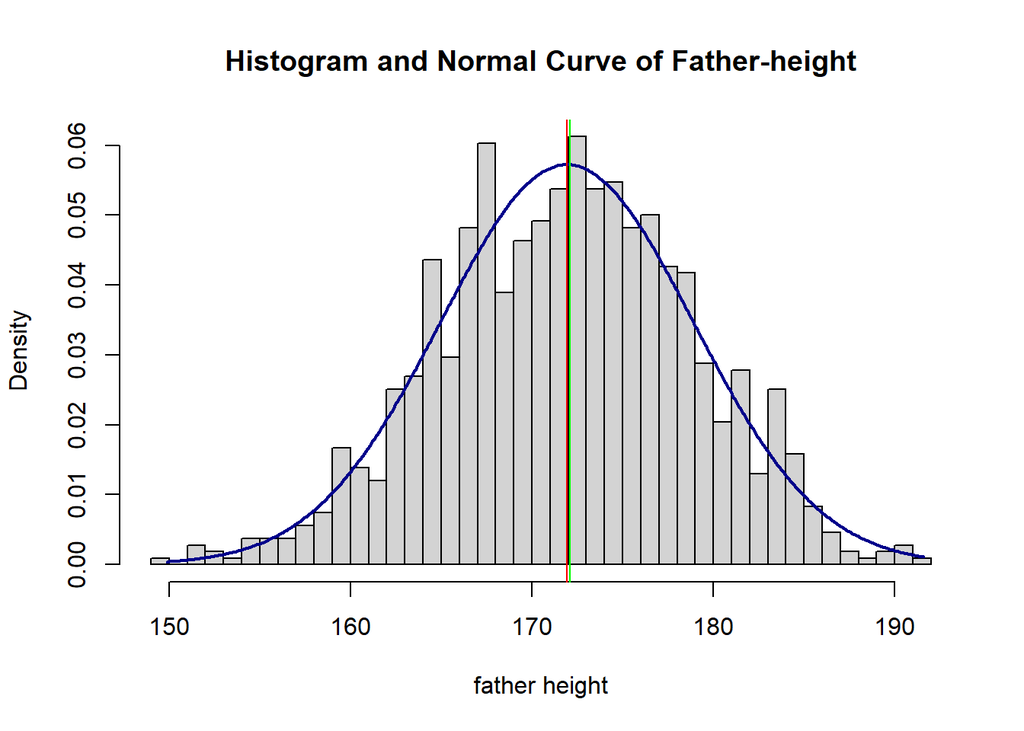

```r
# Normal distribution of fheight
# creating a uniformed space sequence for plotting normal distribution
seq1 <- seq(from = min(df_height$fheight), to = max(df_height$fheight), by = 0.1)

hist(df_height$fheight, breaks = 30, prob = TRUE, main = 'Histogram and Normal Curve of Father-height', xlab = 'father height', ylab = 'Density')

curve(dnorm(x, mean=171.92, sd =  6.97),
       from = min(df_height$fheight), to = max(df_height$fheight), n = length(seq1),
      col="darkblue", lwd=2, add=TRUE, yaxt="n")
abline(v = 171.92, col = "red")
abline(v = 172.1, col = "green")
```

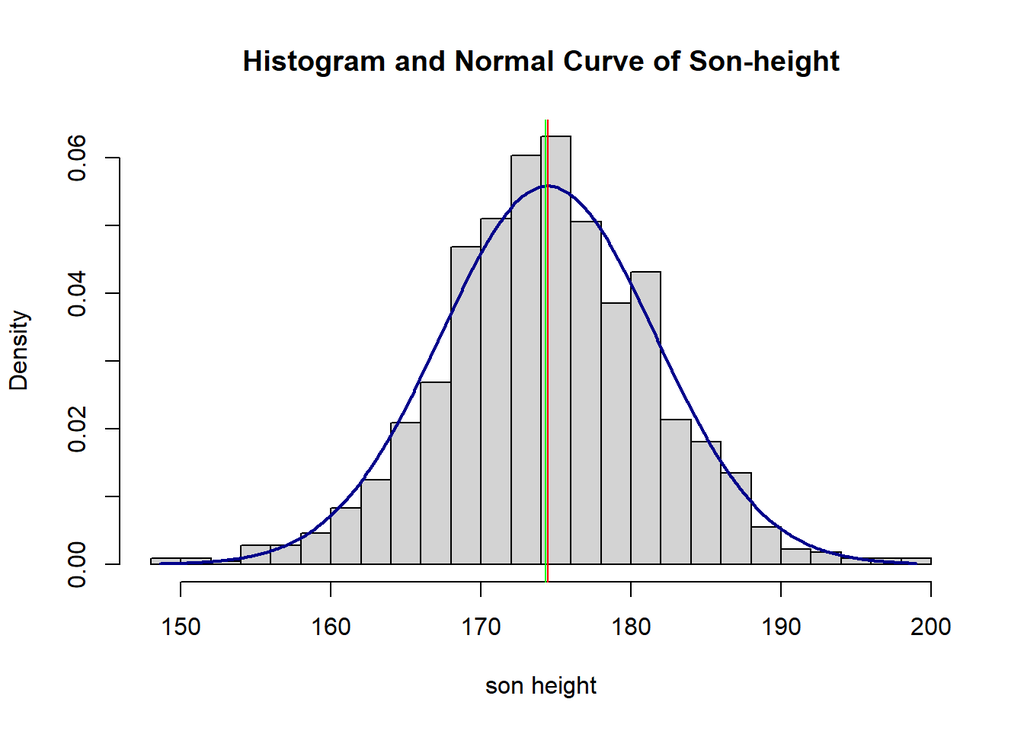

```r
# Normal distribution of sheight

# creating a uniformed space sequence for plotting normal distribution
seq2 <- seq(from = min(df_height$sheight), to = max(df_height$sheight), by = 0.1)

hist(df_height$sheight, breaks = 30, prob = TRUE, main = 'Histogram and Normal Curve of Son-height', xlab = 'son height', ylab = 'Density')
curve(dnorm(x, mean=174.46, sd =  7.15),
      from = min(df_height$sheight), to = max(df_height$sheight), n= length(seq2),
      col="darkblue", lwd=2, add=TRUE, yaxt="n")
abline(v = 174.46, col = "red")
abline(v = 174.3, col = "green")
```

#### (b) Next, let’s take a look at the number of citations of research papers.

```r
#Importing data

citation_data <- readr::read_csv("C:\\CodeR - DataSci1\\PS-5\\mag-in-citations.csv.bz2")
colnames(citation_data)
```

```
## [1] "paperId"   "citations"
```

```r
glimpse(citation_data)
```

```
## Rows: 388,258
## Columns: 2
## $ paperId   <dbl> 4090687, 6537979, 7484482, 9444380, 14056478, 14498457, 1...
## $ citations <dbl> 2, 2, 4, 3, 5, 2, 1, 39, 9, 1, 0, 0, 16, 2, 6, 4, 0, 2, 9...
```

1. What kind of measure is the citation counts for research papers (i.e. the number of times that a paper is referenced by other papers)? How should it be measured (e.g. continuous, discrete, positive, negative…)?

**Solution:**

The citation counts is ratio variable. It will be measured as a discrete.

2. Read the data. This is Microsoft Academic Graph for citations of research papers, and it contains two columns: paper id and number of citations. We only care about citations here. Provide basic descriptive of this variable: how many observations do we have? Do we have any missing observations?

**Solution:**

```r
glimpse(citation_data)
```

```
## Rows: 388,258
## Columns: 2
## $ paperId   <dbl> 4090687, 6537979, 7484482, 9444380, 14056478, 14498457, 1...
## $ citations <dbl> 2, 2, 4, 3, 5, 2, 1, 39, 9, 1, 0, 0, 16, 2, 6, 4, 0, 2, 9...
```

```r
colSums(is.na(citation_data))
```

```
##   paperId citations
##         0         0
```

```r
filter(df_height, df_height == 0)
```

```
## [1] fheight sheight
## <0 rows> (or 0-length row.names)
```

3. Compute mean, median, mode, standard deviation and range of the citations. Discuss the relationship between these numbers. Is mean larger than median? Than mode? By how much (in relative terms)? What does this suggest? How does standard deviation compare to mean?

**Solution:**

1. Mean is larger than the median and mode
2. Difference: mean & median - 12.6 mean & mode - 15.6
3. As the data is skewed, median will be better representation of typical value than mean.
4. As standard deviation is more i.e 78.39 meaning spread is more, the normal distribution’s 68/95/99.7 rule will not be applicable here.

```r
# mean, median, mode, sd and range of citations

mean(citation_data$citations)
```

```
## [1] 15.61223
```

```r
median(citation_data$citations)
```

```
## [1] 3
```

```r
mlv(citation_data$citations, na.rm = TRUE, method = "mfv")
```

```
## [1] 0
```

```r
sd(citation_data$citations)
```

```
## [1] 78.39079
```

```r
q1 <- quantile(citation_data$citations, 0.25)
q3 <- quantile(citation_data$citations, 0.75)
iqr <- q3 -q1
iqr
```

```
## 75%
##  11
```

```r
# ggplot(citation_data, aes(citation_data$citations)) + geom_histogram()
```

4. On the same plot, overlay a plot of the normal distribution with the same mean and standard deviation as the data. Additionally, indicate the mean and median of the data using vertical lines of different colors. What do you find? Are the histogram and the density plot similar? Now try this with what is called a “log-log” transformation (i.e. plotting the x and y axes on a logarithmic scale)

**Solution:**

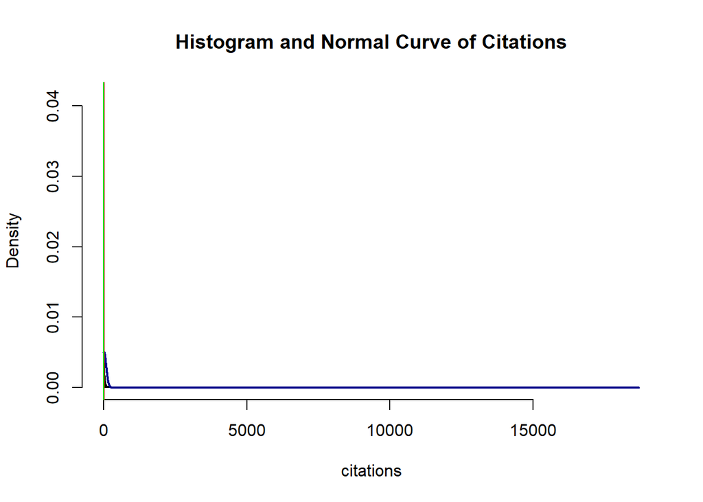

```r
# Normal distribution of citations data
# creating a uniformed space sequence for plotting normal distribution
seq3 <- seq(from = min(citation_data$citations), to = max(citation_data$citations), by = 1)


hist(citation_data$citations, breaks = 1000, prob = TRUE, main = 'Histogram and Normal Curve of Citations', xlab = 'citations', ylab = 'Density')
curve(dnorm(x, mean=15.61, sd =  78.39),
      from = min(citation_data$citations), to = max(citation_data$citations), n = length(seq3),
      col="darkblue", lwd=2, add=TRUE, yaxt="n")
abline(v = 15.61, col = "red")
abline(v = 3, col = "green")
```

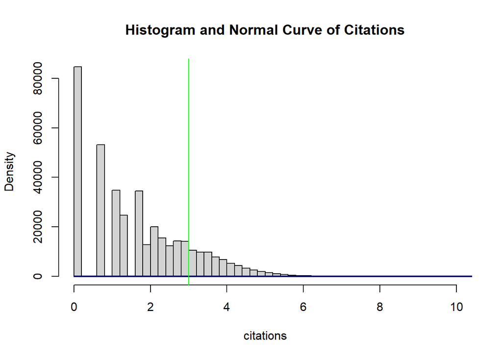

```r
#Log Transformation
#Creating a uniformed space sequence for plotting normal distribution
seq3 <- seq(from = min(citation_data$citations), to = max(citation_data$citations), by = 1)

hist(log(citation_data$citations+1), breaks = 40, freq = TRUE, main = 'Histogram and Normal Curve of Citations', xlab = 'citations', ylab = 'Density')
curve((dnorm(x, mean=15.61, sd =  78.39)),
      from = min(citation_data$citations), to = max(citation_data$citations), n = length(seq3),
      col="darkblue", lwd=2, add=TRUE, yaxt="n")
abline(v = 15.61, col = "red")
abline(v = 3, col = "green")
```

#### (c) Comment on your finding from part (a) and part (b). Be sure to compare the two cases. That is, seeing how well (or not well) that the heights and the citations datasets align with the normal distribution, what are your thoughts on these datasets and do the findings make sense with respect to what we’d expect to see concerning heights and influence (as measured by citations)?

**Solution:**

The heights data aligns well with the normal distribution. The citations data set doesn’t align properly with the normal distribution and is right-skewed. I believe the heights data set makes sense, having more people of average height, and less people of below & more than average heights. In case of the citations dataset, more than 80000 articles are not cited. I think this data also make sense because the number of handful popular articles are cited more. While some unpopular articles are not even cited once.